# Day11: はじめての d3.js

# はじめに

これまでは R を使った可視化を行ってきました． 本日からはウェブブラウザを使った可視化に挑戦します． 具体的には，HTML + CSS + JavaScript による可視化となります． 可視化ライブラリとして d3.js(https://d3js.org/) を使います． python の簡易HTTPサーバ機能を利用します． ウェブブラウザにはGoogle Chromeを使います．

# 準備

ウェブサーバで公開するディレクトリ（ドキュメントルート）に以下の3つのファイルを用意します. すべてのファイルの文字コードは「UTF8」としてください．

- DocumentRoot/
  - index.html
  - style.css
  - script.js

「DocumentRoot」は英字（スペースなし）であれば， 適当な名前に変更してもらっても構いません．

## index.html

メインとなるHTML（HyperText Markup Language）ファイルです．

```
<!DOCTYPE html>
<html lang="ja">
  <head>
    <meta charset="utf-8">
    <title>情報応用論（テキスト処理）演習</title>
    <!-- d3.jsライブラリの読み込み -->
    <script src="http://d3js.org/d3.v3.min.js" charset="utf-8"></script>
    <!-- スタイルシート -->
    <link rel="stylesheet" href="style.css" type="text/css" />
    <!-- 処理用スクリプト -->
    <script type="text/javascript" src="script.js" ></script>
  </head>
  <body>
    <div id="screen"></div>
  </body>
</html>
```

## style.css

HTMLの見た目を定義するスタイルシートです.

```
#screen {
    // 背景は黒
    background: #000000;
}
#svg {
    // SVG領域の背景は白
    background: #ffffff;
}
```

## script.js

d3.jsの処理内容を記述するJavaScriptです.

```
/* onloadで呼び出される関数 */
function init(){

};
```

# HTTPサーバの起動と停止

## 起動

コマンドプロンプトを開き， DocumentRootに移動してください．

DocumentRootに移動したら，下記コマンドを入力してHTTPサーバを起動してください．

```
python -m SimpleHTTPServer
```

起動に成功すると，下記メッセージが表示されます．

```
Serving HTTP on 0.0.0.0 port 8000 ...
```

ウェブブラウザを起動し，下記アドレスにアクセスします．

```
http://localhost:8000
```

画面が表示されればHTTPサーバ起動完了です．

python 3.x系の場合は下記コマンドを入力してください．

```
python -m http.server
```

## 停止

HTTPサーバを停止する場合はコマンドプロンプトで Ctrl + C を入力します．

# 基本概念の理解

HTMLやJavaScriptを聞いたこともないという人は 解らないことがでてきたら以下サイト等で調べてみてください．

- とほほのWWW入門(http://www.tohoho-web.com/www.htm) 昔からあるサイト．情報が多い．
  - Webページ作成入門(http://www.tohoho-web.com/wwwbeg.htm)
  - とほほのJavaScriptリファレンス(http://www.tohoho-web.com/js/)
- JavaScript超初心者によるJavaScript入門講座(http://piyo-js.com/) コンパクトで分かりやすくまとまている．
- Mozilla Developer Network: JavaScript (https://developer.mozilla.org/ja/docs/Web/JavaScript): 詳しい．リファレンスも揃っている．

それでは始めましょう．

## HTML(HyperText Markup Language)

HTMLはウェブ文書を記述するためのマークアップ言語です．

前述の「[index.html」のような文書をHTMLで記述されたHTML文書と呼びます．

HTML文書は要素から構成されます．要素とは例えば下記のようなイメージとなります．

```
 <title>情報応用論（テキスト処理）演習</title>
```

この例はindex.htmlのtitle要素を抜き出したものとなります．

また，要素は基本的にタグと値から構成されています． 値は開始タグと終了タグで囲まれています（これを値をタグでマークアップするという）．

```
<開始タグ>値</終了タグ>
```

HTMLでは各タグにそれぞれ意味付けがされています． たとえば，先程のtitleタグはウェブ文書のタイトルを意味します． ウェブブラウザはこの意味を解釈することで， ウェブページを描画します．

現時点のHTMLの最新バージョンは「HTML5」となります．

- https://www.w3.org/TR/html5/

HTML5を詳しく知りたい方は下記サイト等を御覧ください．

- http://www.html5.jp/

## JavaScript

JavaScript はウェブブラウザで動作するプログラミング言語です． ウェブプログラミングの世界で広く使われている言語の一つで， いまも活発に開発が進められています．

基本的にウェブブラウザの実装によるのですが， ECMAScript として標準化が行われています．

- https://tc39.github.io/ecma262/
- https://github.com/tc39/ecma262

プログラミング言語としての進化も著しいため， 同じ手続きでも複数の書き方があったりします．

はじめは混乱するかもしれませんが， 手軽にウェブブラウザで動作を検証できるので， まずは動かしてみる，といった気持ちでいくと良いと思います．

## DOM(Document Object Model)

DOMはHTML文書をツリー構造で処理するAPI（Application Programming Interface）です．

たとえば，前述の「index.html」はDOMでは以下のようにツリー構造に変換されます．

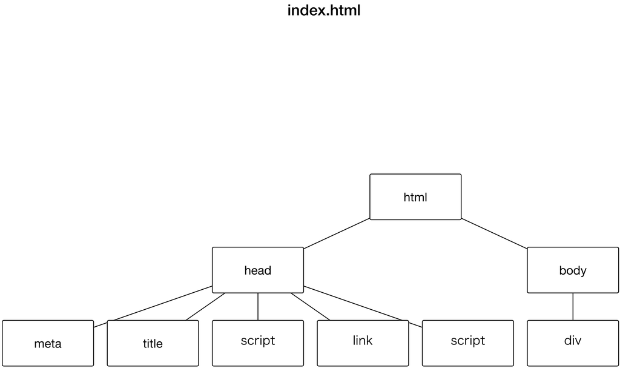

Chromeのデベロッパーツールを使うとDOMをイメージしやすいかもしれません．

デベロッパーツールは，Chrome で「index.html」を開き， メニュー>その他ツール>デベロッパーツールをクリックすると起動できます．

[figure not shown]

Element タブを開くと， 表示しているウェブページのHTML構造を確認することができます．

HTML要素をクリックすると画面の下方にパンくずリストが表示されます．

このようにHTML文書をツリー構造で処理するのがDOM機能となります．

## SVG（Scalable Vector Graphics）

SVG（Scalable Vector Graphics）はXMLベースの二次元画像形式の一種です． ベクトル形式の画像形式であるため，拡大・縮小しても元の画像の内容を保つことが可能です． ラスタ形式の画像のように，拡大するとドットが目立つような事象はおきません．

SVGにはXMLのアプリケーションであり， 図形描画のための要素が定義されています．

以下にSVGの例を示します．

```
<svg width="800" height="600">
  <rect x="1" y="1" width="50" height="50" fill="none" stroke="blue" stroke-width="2"/>
</svg>
```

このSVG文書をSVG対応のソフトウェアで読み込むと矩形が表示されます．

要素の定義を詳しく知りたい方は下記サイトを参照してください．

- http://www.w3.org/TR/SVG/shapes.html

## d3.js

d3.js(https://d3js.org/)は データ駆動プログラミングを可能にするJavaScrptライブラリとなります． 具体的には演習を通じて体験してもらいますが， イメージ的には「与えられたデータに対応してDOMを操作する」形でプログラミングしていきます．

どういったことが実現できるかは下記サンプル紹介サイトをご覧ください．

- https://github.com/d3/d3/wiki/Gallery

# 演習

## HTMLを使ってみる

### title要素の変更

index.htmlのtitle要素の値を以下を参考に編集し， ウェブブラウザから変更が反映されていることを確認してください．

※ウェブサーバが起動していない場合は起動させてください．

```
<title>情報応用論（テキスト処理）演習:学籍番号</title>
```

### body要素への要素追加

index.htmlのbody要素に以下の要素を追加してください． また，要素追加後のウェブブラウザで変更内容を確認してください．

これを

```
  <body>
    <div id="screen"></div>
  </body>
```

こうする

```
  <body>
    <h1>heading1</h1>
    <div id="screen"></div>
    <h2>heading2</h2>
  </body>
```

### img要素の追加

DocumentRootに適当な画像ファイルを置き， ウェブブラウザで表示できるようindex.htmlを編集してください． 編集後，http://localhost:8000/ にアクセスし，画像が表示されていることを確認してください．

これを

```
  <body>
    <h1>heading1</h1>
    <div id="screen"></div>
    <h2>heading2</h2>
  </body>
```

こうする(demo.pngは適宜変更する)

```
  <body>
    <h1>heading1</h1>
    <div id="screen"></div>
    <h2>heading2</h2>
    <img src="demo.png" width="300px" height="200px" alt="画像が表示できません"/>
  </body>
```

## SVGを使ってみる

### 簡単な図形表示

SVGを使って簡単な図形を表示してみましょう． index.htmlを以下のように書き換えてください．

```
<!DOCTYPE html>
<html lang="ja">
  <head>
    <meta charset="utf-8">
    <title>情報応用論（テキスト処理）演習</title>
    <!-- d3.jsライブラリの読み込み -->
    <script src="http://d3js.org/d3.v3.min.js" charset="utf-8"></script>
    <!-- スタイルシート -->
    <link rel="stylesheet" href="style.css" type="text/css" />
    <!-- 処理用スクリプト -->
    <script type="text/javascript" src="script9.js" ></script>
  </head>
  <body>
    <div id="screen">
      <svg width="800" height="600">
        <rect x="1" y="1" width="50" height="50" fill="none" stroke="blue" stroke-width="2"/>
      </svg>
    </div>
  </body>
</html>
```

いかがでしょう．正方形が表示されたと思います．

つぎにfill属性の値を「none」から「yellow」に変更してみてください．

fill属性，stroke属性には「yellow」のような色名だけでなく， RGB値を「#FF0000」のように指定することもできます．

### 図形の追加

先程のrect要素のつぎに以下のコードを追記してください．

```
<circle cx="400" cy="300" r="100" fill="red" stroke="blue" stroke-width="10"  />
```

index.html 全体は以下のようになります．

```
<!DOCTYPE html>
<html lang="ja">
  <head>
    <meta charset="utf-8">
    <title>情報応用論（テキスト処理）演習</title>
    <!-- d3.jsライブラリの読み込み -->
    <script src="http://d3js.org/d3.v3.min.js" charset="utf-8"></script>
    <!-- スタイルシート -->
    <link rel="stylesheet" href="style.css" type="text/css" />
    <!-- 処理用スクリプト -->
    <script type="text/javascript" src="script9.js" ></script>
  </head>
  <body>
    <div id="screen">
      <svg width="800" height="600">
        <rect x="1" y="1" width="50" height="50" fill="none" stroke="blue" stroke-width="2"/>
        <circle cx="400" cy="300" r="100" fill="red" stroke="blue" stroke-width="10"  />
      </svg>
    </div>
  </body>
</html>
```

いかがでしょう，今度は円が表示されたと思います．

## JavaScript を使ってみる

### 「Hello,World!」の表示

それでは画面に「Hello,World!」と表示するJavaScriptを書いてみましょう．

index.htmlを以下のように変更してください．新たにimg要素の次にscript要素を追加しています．

```
<!DOCTYPE html>
<html lang="ja">
  <head>
    <meta charset="utf-8">
    <title>情報応用論（テキスト処理）演習:学籍番号</title>
    <!-- d3.jsライブラリの読み込み -->
    <script src="http://d3js.org/d3.v3.min.js" charset="utf-8"></script>
    <!-- スタイルシート -->
    <link rel="stylesheet" href="style.css" type="text/css" />
    <!-- 処理用スクリプト -->
    <script type="text/javascript" src="script.js" ></script>
  </head>
  <body>
    <h1>heading1</h1>
    <div id="screen"></div>
    <h2>heading2</h2>
    <img src="demo.png" width="300px" height="200px" alt="画像が表示できません"/>
    <script type="text/javascript">
      alert("Hello,World!");
    </script>
  </body>
</html>
```

ウェブブラウザで動作を確認してください．

alert関数は簡単な警告を表示する場合などに用いられます．

リファレンスはこちら．

- https://developer.mozilla.org/ja/docs/Web/API/Window/alert

### 「Hello,World!」の表示2

今度はデベロッパーツールのコンソールに「Hello,World!」を表示してみましょう． 先程の「Hello,World」表示に用いた alert 関数を console.log 関数に変更してください．

```
<!DOCTYPE html>
<html lang="ja">
  <head>
    <meta charset="utf-8">
    <title>情報応用論（テキスト処理）演習:学籍番号</title>
    <!-- d3.jsライブラリの読み込み -->
    <script src="http://d3js.org/d3.v3.min.js" charset="utf-8"></script>
    <!-- スタイルシート -->
    <link rel="stylesheet" href="style.css" type="text/css" />
    <!-- 処理用スクリプト -->
    <script type="text/javascript" src="script.js" ></script>
  </head>
  <body>
    <h1>heading1</h1>
    <div id="screen"></div>
    <h2>heading2</h2>
    <img src="demo.png" width="300px" height="200px" alt="画像が表示できません"/>
    <script type="text/javascript">
      console.log("Hello,World!");
    </script>
  </body>
</html>
```

ウェブブラウザを開き，http://localhost:8000/index.html にアクセスし， デベロッパーツールを開いてください． Consoleタブを開くとメッセージが表示されているはずです．

alertよりも気軽にメッセージを出力可能なconsole.log関数はJavascriptのデバッグに便利な関数です．

リファレンスはこちら．

- https://developer.mozilla.org/ja/docs/Web/API/Console/log

標準ではないがほとんどのブラウザで使用できる．

### 日付の表示

もう少し複雑なことをしてみましょう．script要素を下記内容で置き換えてください．

console.log を使って日付を出力しています．

```
    <script type="text/javascript">
      // 現在の日付を格納したDateオブジェクトを生成する
      var date = new Date();
      var year = date.getFullYear();
      var month = date.getMonth();
      var day = date.getDate();
      console.log(date);
      console.log(year);
      console.log(month);
      // month に1を加算し，出力している．
      console.log(month+1);
      console.log(day);
      // month に1を加算し，加算後の値をmonthに代入している
      month = month + 1;
      // 文字列は+で連結できる
      console.log(year+"/"+month+"/"+day);
    </script>
```

https://developer.mozilla.org/ja/docs/Web/JavaScript/Reference/Global_Objects/Date

### 関数定義

JavaScriptでは独自関数を定義することができます． script要素を以下のように書き換えてみてください． ここではhogeという現在の日付を表示する関数を定義しています．

```
    <script type="text/javascript">
      function hoge(){
        var date = new Date();
        var year = date.getFullYear();
        var month = date.getMonth();
        var day = date.getDate();
        month = month + 1;
        console.log(year+"/"+month+"/"+day);
      };

    </script>
```

変更後，ウェブブラウザで動作を確認してみてください．

あれ？何も表示されない？？

関数は定義だけでは動きませんので，ちゃんと呼び出しする必要があります．

先程のスクリプトを以下のように書き換えてください．

```
    <script type="text/javascript">
      function hoge(){
        var date = new Date();
        var year = date.getFullYear();
        var month = date.getMonth();
        var day = date.getDate();
        month = month + 1;
        console.log(year+"/"+month+"/"+day);
      };
      hoge();
    </script>
```

今度はちゃんと表示されたと思います．

### 外部スクリプトの読み込みと関数呼び出し

index.htmlを以下の内容で書き換え， ウェブブラウザの表示内容を確認してください．

```
<!DOCTYPE html>
<html lang="ja">
  <head>
    <meta charset="utf-8">
    <title>情報応用論（テキスト処理）演習</title>
    <!-- d3.jsライブラリの読み込み -->
    <script src="http://d3js.org/d3.v3.min.js" charset="utf-8"></script>
    <!-- スタイルシート -->
    <link rel="stylesheet" href="style.css" type="text/css" />
    <!-- 処理用スクリプト -->
    <script type="text/javascript" src="script.js" ></script>
  </head>
  <!-- HTMLファイル読み込み時に 関数init を呼び出す -->
  <body onload="init();">
    <div id="screen"></div>
  </body>
</html>
```

何も変わっていないですね．．すみません．

body要素にある「onload=“init();”」により， script.jsに定義された関数がページ読み込み時に呼び出されているのですが， init関数には何も書かれていないため，何も動きません．

ためしに script.js を以下のように書き換えてみてください．

```
/* onloadで呼び出される関数 */
function init(){
   console.log("Hello,World!")
};
```

いかがでしょう．コンソールにメッセージが表示されたと思います．

以降はこの script.js を編集していきます．

### DOM経由での要素追加

script.js を下記内容で書き換えてみてください． 結果，どのように表示されるでしょうか．デベロッパーツールのElementsタブも確認してみてください．

```
/* onloadで呼び出される関数 */
function init(){
   var div = document.getElementById("screen");
   var img = document.createElement("img");
   img.id = "newimg";
   img.src = "demo.png";
   img.width = 300;
   img.height = 200;
   div.appendChild(img);
};
```

上記ではまず，要素のidに「screen」とある要素を探してきて，変数に代入します．

```
var div = document.getElementById("screen");
```

ここではid属性に「screen」と指定されているdiv要素が取得される．

つぎに img要素を作成し，変数に代入しています．

```
var img = document.createElement("img");
```

この時点ではまだHTML文書は変更されていません．

その後，img要素の各属性を設定しています．

```
img.id = "newimg";
img.src = "demo.png";
img.width = 300;
img.height = 200;
```

最後にdiv要素の子として作成したimg要素を追加しています．

```
div.appendChild(img);
```

このようにDOMを用いると， 動的にHTML文書を編集することが可能となります．

## d3.jsを使ってみる

### d3.jsによるDOM操作

d3.js は可視化ライブラリですが， 基本的にはDOM操作を行います．

たとえば，前述のDOM経由での要素追加の以下コードは，

```
/* onloadで呼び出される関数 */
function init(){
   var div = document.getElementById("screen");
   var img = document.createElement("img");
   img.id = "newimg";
   img.src = "demo.png";
   img.width = 300;
   img.height = 200;
   div.appendChild(img);
};
```

d3.jsの機能を使って以下のように書き換えることができます．

```
/* onloadで呼び出される関数 */
function init(){
    var width = 300;
    var height = 200;
    // img要素を作成する
    var img = d3.select("#screen")
    .append("img")
    .attr("id","newimg")
    .attr("width",width)
    .attr("height",height)
    .attr("src","demo.png");
};
```

変化がわかりにくいので， width,heightの値を変更してみてください．

以降はd3.jsの書き方でコードを編集していきます．

### d3.jsによるSVG操作（矩形）

d3.js を用いるとSVGの要素も同じようにつくることができます． script.jsを以下のように変更してください．

```
/* onloadで呼び出される関数 */
function init(){
    var width = 800;
    var height = 600;
    // svg要素を作成する
    var svg = d3.select("#screen").append("svg")
    .attr("id","svg")
    .attr("width",width)
    .attr("height",height);
    //　矩形を描く
    svg.append("rect")
    .attr("x",400).attr("y",100)
    .attr("width",400).attr("height",200)
    .attr("fill","yellow")
    .attr("stroke","navy").attr("stroke-width",10);
};
```

http://www.w3.org/TR/SVG/shapes.html#RectElement

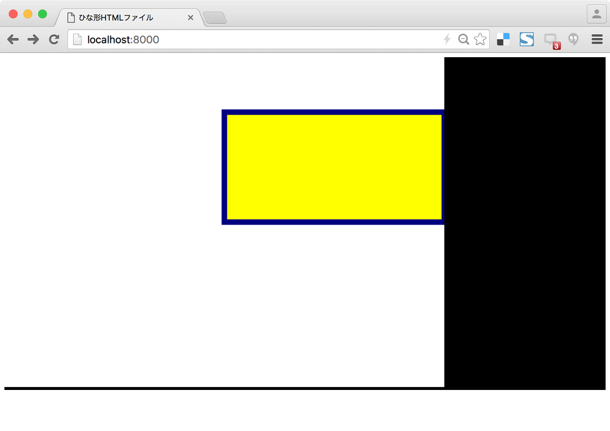

### d3.jsによるSVG操作（円）

今度はd3.jsでSVGのcircle要素を作成してみましょう． script.jsを以下のように変更してください．

```
/* onloadで呼び出される関数 */
function init(){
    var width = 800;
    var height = 600;
    // svg要素を作成する
    var svg = d3.select("#screen").append("svg")
    .attr("id","svg")
    .attr("width",width)
    .attr("height",height);
    // 円を描く
    svg.append("circle")
    .attr("cx",600).attr("cy",200)
    .attr("r",100)
    .attr("fill","red")
    .attr("stroke","blue").attr("stroke-width",10);
};
```

http://www.w3.org/TR/SVG/shapes.html#CircleElement

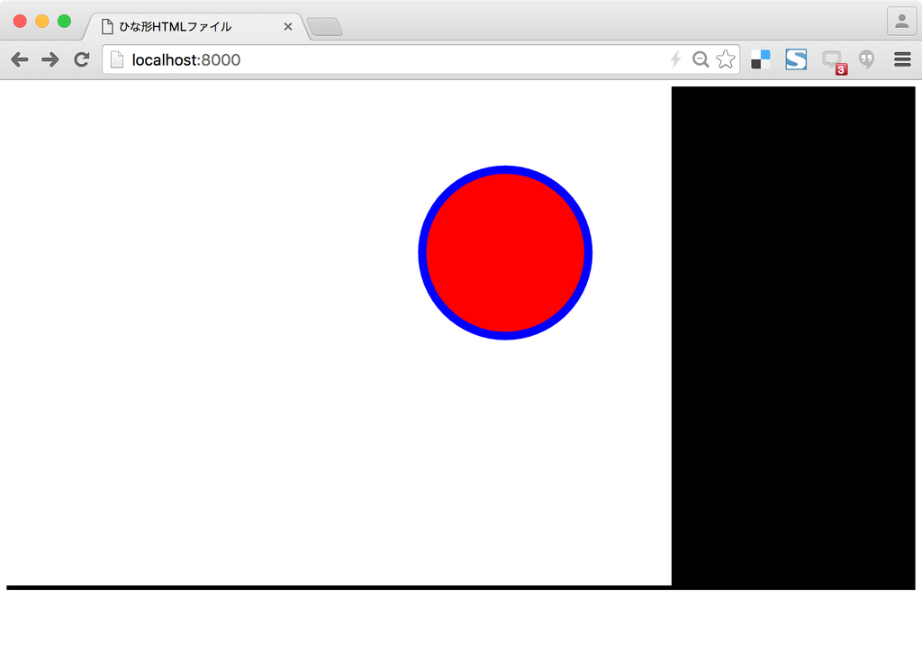

図が描けたら属性値を弄ったり，他のSVG要素を描画して見るように変更してみてください．

### データ駆動型プログラミング

最後にd3.jsの特徴であるデータ駆動型のプログラミングを体験してみます。

まずは、以下のコードを実行してください。

```
/* onloadで呼び出される関数 */
function init(){
    var width = 800;
    var height = 600;
    // svg要素を作成する
    var svg = d3.select("#screen").append("svg")
    .attr("id","svg")
    .attr("width",width)
    .attr("height",height);
    // データを定義する（オブジェクトの配列）
    var data = [{x: 10, y:20, r:10}];
    // データを描画する
    svg.selectAll("circle")
    .data(data)
    .enter()
    .append("circle")
    .attr("cx",function(d){return d.x})
    .attr("cy",function(d){return d.y})
    .attr("r", function(d){return d.r})
    .attr("fill","yellow")
    .attr("stroke","navy").attr("stroke-width",2);
};
```

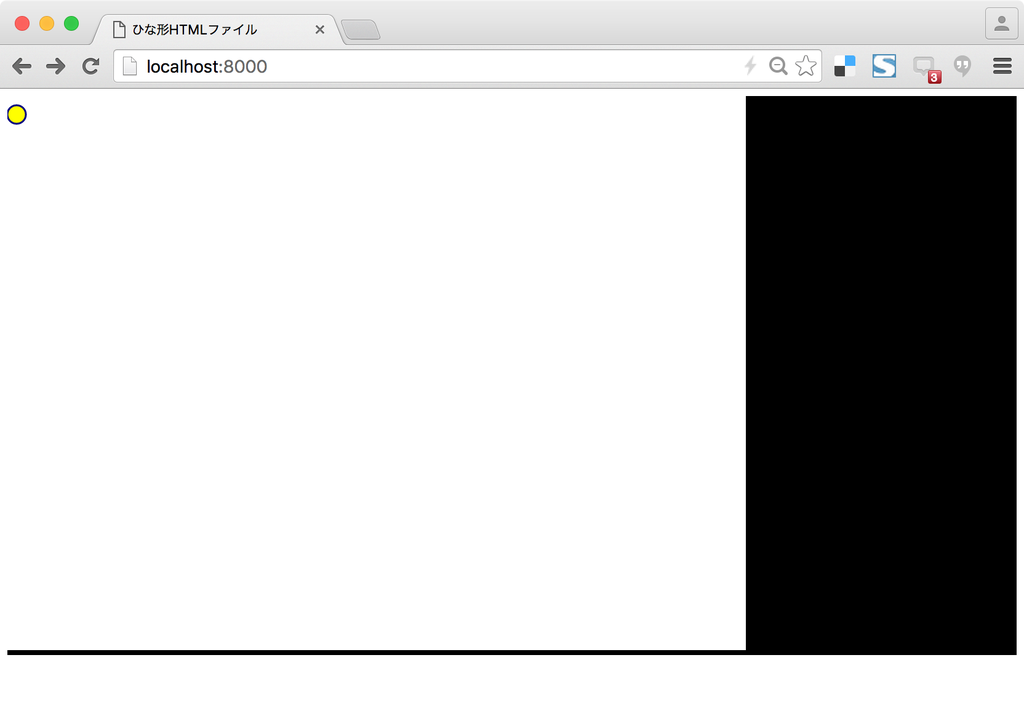

配列dataに格納された値を用いてcircle要素を作成しています．

つぎに先ほどのコードを編集してデータを増やしてみます。

```
/* onloadで呼び出される関数 */
function init(){
    var width = 800;
    var height = 600;
    // svg要素を作成する
    var svg = d3.select("#screen").append("svg")
    .attr("id","svg")
    .attr("width",width)
    .attr("height",height);
    // データを増やす（オブジェクトの配列）
    var data = [{x: 10, y:20, r:10},{x: 100, y:50, r:70},{x: 30, y:90, r:10}];
    // データを描画する
    svg.selectAll("circle")
    .data(data)
    .enter()
    .append("circle")
    .attr("cx",function(d){return d.x})
    .attr("cy",function(d){return d.y})
    .attr("r", function(d){return d.r})
    .attr("fill","yellow")
    .attr("stroke","navy").attr("stroke-width",2);
};
```

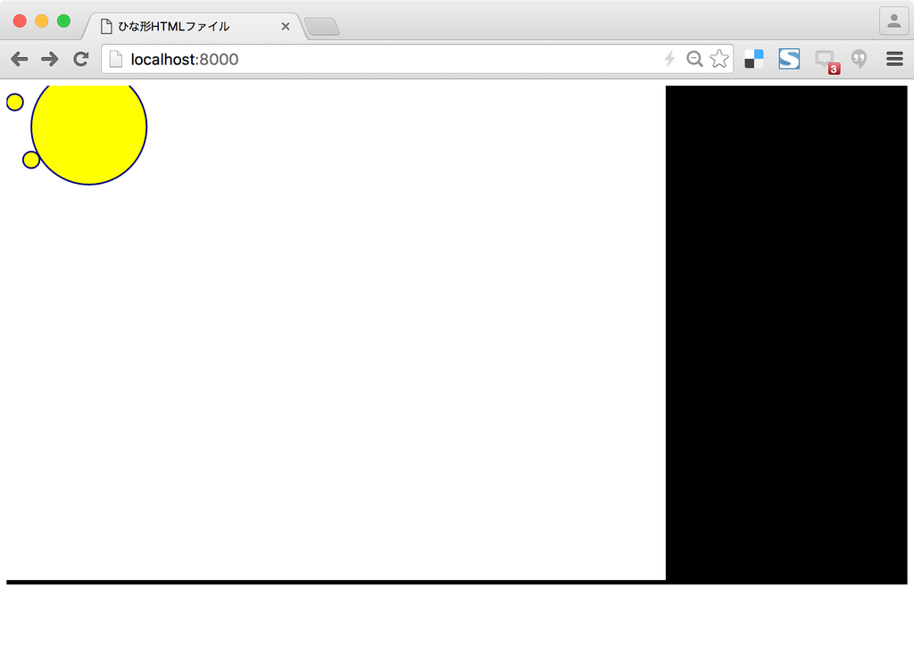

いかがでしょうか。描画される図形が増えたと思います．

同じようにデータを追加してみてください．データの数に応じて描画される図形が増減します．

このようにデータを起源として描画というイベントを駆動するプログラミング手法を データ駆動型プログラミングといいます．

### データ駆動型プログラミング2

もう少しデータ駆動型プログラミングを体験してみましょう． 今度はデータで枠線の色を指定するようにしてみます． script.jsを以下のように変更してみてください．

```
/* onloadで呼び出される関数 */
function init(){
    var width = 800;
    var height = 600;
    // svg要素を作成する
    var svg = d3.select("#screen").append("svg")
    .attr("id","svg")
    .attr("width",width)
    .attr("height",height);
    // データにstroke属性を追加する
    var data = [{x: 10, y:20, r:10, stroke: "#FF0000"},{x: 100, y:50, r:70, stroke: "#0000FF"},{x: 30, y:90, r:10, stroke: "#FF00FF"}];
    // データを描画する
    svg.selectAll("circle")
    .data(data)
    .enter()
    .append("circle")
    .attr("cx",function(d){return d.x})
    .attr("cy",function(d){return d.y})
    .attr("r", function(d){return d.r})
    .attr("fill","yellow")
    // 変更点
    .attr("stroke",function(d){return d.stroke})
    .attr("stroke-width",10);
};
```

いかがでしょうか．まだまだなれないと思いますが， d3.js を使うとインターネット上のオープンデータを直接参照し， グラフを描画するといったことが実現可能となります．

コードを改造するなりして，d3.js の使い方に慣れていってください．

# おわりに

d3.js はいかがでしょうか．少し癖があるのでJavaScriptの経験があっても多少戸惑いがあると思います． また，Rと比較すると，描画の手順等のすべてを書かないといけないので，いかにいままで手抜きができていかがわかると思います．最終的にはRで実現してきた内容を d3.js で再現したいと思っています． 大変ですがあと一息なのでがんばってください．

# 課題

下記課題に挑戦し，script.jsの内容を提出してください．

## d3.js ことはじめ

下記コードを改造し， fill属性，stroke-width属性についても，配列dataの値を利用するようにしてください．

```
/* onloadで呼び出される関数 */
function init(){
    var width = 800;
    var height = 600;
    // svg要素を作成する
    var svg = d3.select("#screen").append("svg")
    .attr("id","svg")
    .attr("width",width)
    .attr("height",height);
    // データにstroke属性を追加する
    var data = [{x: 10, y:20, r:10, stroke: "#FF0000"},{x: 100, y:50, r:70, stroke: "#0000FF"},{x: 30, y:90, r:10, stroke: "#FF00FF"}];
    // データを描画する
    svg.selectAll("circle")
    .data(data)
    .enter()
    .append("circle")
    .attr("cx",function(d){return d.x})
    .attr("cy",function(d){return d.y})
    .attr("r", function(d){return d.r})
    .attr("fill","yellow")
    // 変更点
    .attr("stroke",function(d){return d.stroke})
    .attr("stroke-width",10);
};
```

## 【発展】d3.js ことはじめ

上記課題に加え，circle要素をrect要素に変更したものを提出してください．

戻る

Masaharu Hayashi を著作者とするこの 作品 は [クリエイティブ・コモンズの 表示 4.0 国際 ライセンス](http://creativecommons.org/licenses/by/4.0/)で提供されています。